# AXCPT Psychometrics

Winnie Zhuang (wzhuang@live.ca)

11/17/20

Some functions to assess the psychometrics of AXCPT’s derived measures.

Note: Permutations reduced to 50 for illustrative purposes.

```r
knitr::opts_chunk$set(message = FALSE, warning = FALSE)

library(tidyverse)
library(car)
library(kableExtra)
library(yarrr)
```

# Generate Data

First, let’s make some data to work with.

```r
set.seed(1234)
dt <- expand.grid(
  ntrial=1:20, # number of trials/condition
  id= 1:80, #number of subjects
  trialtype= c("ax","ay","bx","by") #within conditions
)

#make 2 age groups as between subjects condition
dt$age_group<- NA
dt$age_group[dt$id<=40]<-1
dt$age_group[dt$id>40]<-2

#simulate some rts and accs
dt$rt_ms<- rnorm(nrow(dt), mean=400, sd=200)
dt$acc<-sample(x=c(0,1),size=nrow(dt),replace=TRUE,prob=c(.2,.8))

#take a look at dt
dt %>% group_by(age_group,id,trialtype) %>%
  count()
```

```
## # A tibble: 320 x 4
## # Groups:   age_group, id, trialtype [320]
##    age_group    id trialtype     n
##        <dbl> <int> <fct>     <int>
##  1         1     1 ax           20
##  2         1     1 ay           20
##  3         1     1 bx           20
##  4         1     1 by           20
##  5         1     2 ax           20
##  6         1     2 ay           20
##  7         1     2 bx           20
##  8         1     2 by           20
##  9         1     3 ax           20
## 10         1     3 ay           20
## # … with 310 more rows
```

```r
#look at summary stats
dtage<-dt %>% group_by(age_group) %>%
  summarise(subj_count= n_distinct(id),
            rt_mean= mean(rt_ms),
            rt_var=var(rt_ms),
            acc_mean=mean(acc),
            acc_var=var(acc))
dtage
```

```
## # A tibble: 2 x 6
##   age_group subj_count rt_mean rt_var acc_mean acc_var
##       <dbl>      <int>   <dbl>  <dbl>    <dbl>   <dbl>
## 1         1         40    400. 40290.    0.797   0.162
## 2         2         40    401. 38008.    0.8     0.160
```

# Mean RTs

## Calculation

```r
#look at stats by id
dt_rt<-dt %>% group_by(id,trialtype,age_group) %>%
  summarise(rt_mean=mean(rt_ms))
```

## Variability

```r
#Levene's test to see if age groups and trialtypes have same variance
leveneTest(rt_ms~as.factor(age_group)*trialtype,
           data=dt,
           center=mean)
```

```
## Levene's Test for Homogeneity of Variance (center = mean)
##         Df F value Pr(>F)
## group    7  1.0071 0.4239
##       6392
```

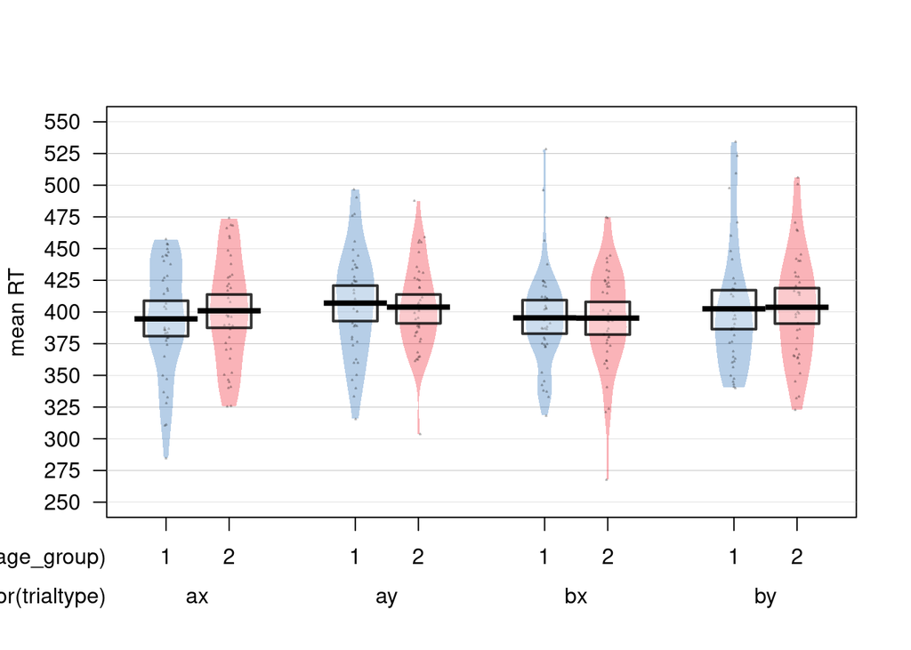

```r
#make a plot of rt by trialtype and age group
pirateplot(formula= rt_mean~factor(age_group)*factor(trialtype),
           data=dt_rt,
           bean.f.o = .3, # customize bean (i.e. violin)
           bean.b.o= 0,
           point.o = 0.3,#customize points
            point.pch = 2,
           point.col = "black",
           point.cex = 0.1,
           inf.f.o = .3, # Inference fill
           #xlab="Age Group",#labels
           ylab="mean RT",
           theme=1)
```

No differences in variances between groups here. Makes sense since the data were generated from the same distribution.

## Reliability

Internal consistency reliability= how well the scores across instances/items are correlated.

```r
#create a df with just the necessary info
dt_shr_rt<-dt %>%
  subset(select=c(id,age_group,trialtype,rt_ms)) #might also exclude incorrect trials. Here they've been included in the example.

#now a df to store output
shr_meanrt<-data.frame(n_rep=integer(),
                    age_group=character(),
                    trialtype=character(),
                     meanrt_splithalf=double(),
                     meanrt_sb=double())

tot_rep<- 50 #specify number of permutations per subject
cur_rep<-0

#now let's loop! This might take a while...
while (cur_rep<=tot_rep){
  cur_rep<-cur_rep+1

  #first, split trial type in each subject into two random halves
  tmp_dt1<-dt_shr_rt %>%
    group_by(age_group, id,trialtype) %>%
    mutate(repSet=sample(
      rep(c("A","B"),length.out=n(),size=n())
    ))

  #get means for each subject, trialtype, and half
  tmp_dt2<-tmp_dt1 %>% group_by(age_group,id, trialtype, repSet) %>%
    summarise(mean_rt=mean(rt_ms)) #change this into

  #make wider
  tmp_dt3<-tmp_dt2 %>%
    pivot_wider(id_cols=c(trialtype, age_group,id),
                names_from=c(repSet),
                values_from=mean_rt)

  #get corrs by age group and trial type
  tmp_dt4 <- tmp_dt3 %>% group_by(age_group,trialtype) %>%
    summarise(tmp_meanrt_corr=cor(A,B,use="complete.obs"), # regular corr
              tmp_meanrt_sb=(2*tmp_meanrt_corr)/(1+tmp_meanrt_corr)) #spearman brown

  #add corr and sb to dataframe
  shr_meanrt<-add_row(shr_meanrt,
                    n_rep=seq(cur_rep,cur_rep,length.out=8),
                    age_group=as.factor(tmp_dt4$age_group),
                    trialtype=tmp_dt4$trialtype,
                    meanrt_splithalf=tmp_dt4$tmp_meanrt_corr,
                    meanrt_sb=tmp_dt4$tmp_meanrt_sb)
}

#get final split half estimates
dtsum_shr_meanrt<-shr_meanrt %>%
  group_by(age_group,trialtype) %>%
  summarise(splithalf=round(mean(meanrt_splithalf),3),
            splithalf5= quantile(meanrt_splithalf,probs=c(.05,.95))[1],
            splithalf95= quantile(meanrt_splithalf,probs=c(.05,.95))[2],
            sb= mean(meanrt_sb),
            sb5= quantile(meanrt_sb,probs=c(.05,.95))[1],
            sb95= quantile(meanrt_sb,probs=c(.05,.95))[2])


#rearrange cols
kable_styling(kable(dtsum_shr_meanrt,digits=4,
                    caption="mean RT split half reliabilities (50 iterations)"))#make table look nice
```

mean RT split half reliabilities (50 iterations)

| age_group | trialtype | splithalf | splithalf5 | splithalf95 | sb | sb5 | sb95 |
| --- | --- | --- | --- | --- | --- | --- | --- |
| 1 | ax | -0.003 | -0.1604 | 0.1390 | -0.0268 | -0.3822 | 0.2441 |
| 1 | ay | -0.066 | -0.2210 | 0.0663 | -0.1644 | -0.5675 | 0.1243 |
| 1 | bx | -0.075 | -0.2310 | 0.0980 | -0.1945 | -0.6026 | 0.1785 |
| 1 | by | 0.161 | 0.0108 | 0.3293 | 0.2598 | 0.0214 | 0.4954 |
| 2 | ax | -0.012 | -0.1709 | 0.1995 | -0.0532 | -0.4126 | 0.3326 |
| 2 | ay | -0.238 | -0.3829 | -0.0890 | -0.6693 | -1.2408 | -0.1971 |
| 2 | bx | -0.065 | -0.2341 | 0.1404 | -0.1766 | -0.6114 | 0.2462 |
| 2 | by | 0.017 | -0.1517 | 0.1810 | 0.0094 | -0.3577 | 0.3064 |

The reliabilities in this example are pretty poor. This is expected, given that the data for each trial was drawn from the same distribution.

# Error Rates

## Calcuation

error rate = (number of errors + 0.5)/(number of trials + 1) <-from Gonthier et al. 2018

```r
#get mean error rate  for each individual and trialtype
dt_err<-dt %>%
  group_by(id,age_group,trialtype) %>%
  summarise(count_acc=sum(acc),
              trial_num=n(),
              count_err=n()-sum(acc)) %>%
  mutate(mean_err=(count_err+0.5)/(trial_num+1))
```

## Variability

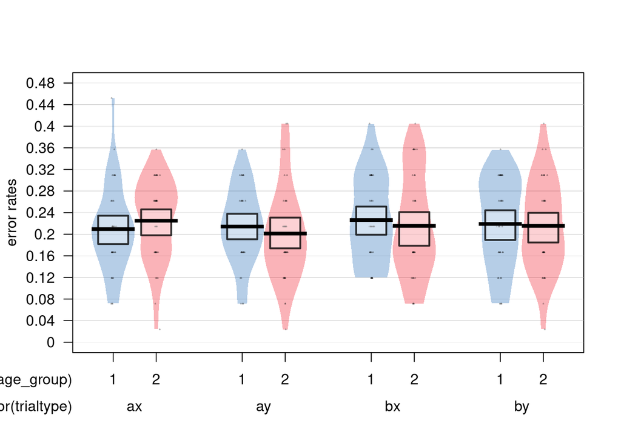

```r
#view error rates for each trialtype and age group
pirateplot(formula= mean_err~factor(age_group)*factor(trialtype),
           data=dt_err,
           bean.f.o = .3, # customize bean (i.e. violin)
           bean.b.o= 0,
           point.o = 0.3,#customize points
            point.pch = 2,
           point.col = "black",
           point.cex = 0.1,
           inf.f.o = .4, # Inference fill
           #xlab="Age Group",#labels
           ylab="error rates",
           theme=1)
```

## Reliability

```r
#create a df with just the necessary info
dt_shr_err<-dt %>%
  subset(select=c(id,age_group,trialtype,acc)) #might also exclude incorrect trials. Here they've been included in the example.

#now a df to store output
shr_err<-data.frame(n_rep=integer(),
                    age_group=character(),
                    trialtype=character(),
                       err_splithalf=double(),
                       err_sb=double())

tot_rep<- 50 #specify number of permutations per subject
cur_rep<-0

while (cur_rep<=tot_rep){
  cur_rep<-cur_rep+1

  tmp_dt1<-dt_shr_err %>%
    group_by(age_group, id,trialtype) %>%
    mutate(repSet=sample(
      rep(c("A","B"),length.out=n(),size=n())
    ))

  #get mean RTs for each subject, trialtype, and half
  tmp_dt2<-tmp_dt1 %>% group_by(age_group,id, trialtype, repSet) %>%
    summarise(count_acc=sum(acc),
              trial_num=n(),
              count_err=n()-sum(acc)) %>%
    mutate(mean_err=(count_err+0.5)/(trial_num+1))

  #make widerand get corrs
  tmp_dt3<-tmp_dt2 %>%
    pivot_wider(id_cols=c(trialtype, age_group,id),names_from=c(repSet),
                                   values_from=mean_err)

  #get corrs by age group and trial type
  tmp_dt4 <- tmp_dt3 %>% group_by(age_group,trialtype) %>%
    summarise(tmp_err_corr=cor(A,B,use="complete.obs"),
              tmp_err_sb=(2*tmp_err_corr)/(1+tmp_err_corr))

  #add corr and sb to dataframe
  shr_err<-add_row(shr_err,
                    n_rep=seq(cur_rep,cur_rep,
                              length.out=nrow(tmp_dt4)),
                    age_group=as.factor(tmp_dt4$age_group),
                    trialtype=tmp_dt4$trialtype,
                    err_splithalf=tmp_dt4$tmp_err_corr,
                    err_sb=tmp_dt4$tmp_err_sb)
}

#get final split half estimates
dtsum_shr_err<-shr_err %>%
  group_by(age_group,trialtype) %>%
  summarise(splithalf=round(mean(err_splithalf),3),
            splithalf5= quantile(err_splithalf,probs=c(.05,.95))[1],
            splithalf95= quantile(err_splithalf,probs=c(.05,.95))[2],
            sb= mean(err_sb),
            sb5= quantile(err_sb,probs=c(.05,.95))[1],
            sb95= quantile(err_sb,probs=c(.05,.95))[2])


#rearrange cols
kable_styling(kable(dtsum_shr_err,digits=4,
                    caption="AXCPT: mean error rate split half reliabilities (50 iterations)"))
```

AXCPT: mean error rate split half reliabilities (50 iterations)

| age_group | trialtype | splithalf | splithalf5 | splithalf95 | sb | sb5 | sb95 |
| --- | --- | --- | --- | --- | --- | --- | --- |
| 1 | ax | -0.069 | -0.2219 | 0.1032 | -0.1792 | -0.5705 | 0.1867 |
| 1 | ay | -0.211 | -0.3744 | -0.0410 | -0.5817 | -1.1991 | -0.0855 |
| 1 | bx | -0.069 | -0.2493 | 0.0897 | -0.1756 | -0.6645 | 0.1646 |
| 1 | by | -0.036 | -0.2037 | 0.1348 | -0.1013 | -0.5120 | 0.2376 |
| 2 | ax | -0.155 | -0.2853 | 0.0083 | -0.3929 | -0.7992 | 0.0165 |
| 2 | ay | 0.067 | -0.0774 | 0.2349 | 0.1067 | -0.1678 | 0.3804 |
| 2 | bx | 0.122 | -0.0451 | 0.3056 | 0.1980 | -0.0944 | 0.4681 |
| 2 | by | -0.014 | -0.1892 | 0.1541 | -0.0523 | -0.4672 | 0.2670 |

# PBI-RT

## Calcuation

Can swap mean RTs with error rates.

```r
dt_pbirt<-dt %>%
  filter(trialtype=="ay"|trialtype=="bx") %>%
  subset(select=c(id,age_group,trialtype,rt_ms)) %>%
  group_by(age_group,id,trialtype) %>%
  summarise(meanrt_ms=mean(rt_ms)) %>%
  pivot_wider(id_cols=c(id,age_group),
                names_from=c(trialtype),
                values_from=meanrt_ms) %>%
  mutate(pbirt=(ay - bx)/(ay + bx))
```

## Variability

```r
leveneTest(pbirt~as.factor(age_group),data=dt_pbirt,center=mean)
```

```
## Levene's Test for Homogeneity of Variance (center = mean)
##       Df F value Pr(>F)
## group  1   2e-04 0.9885
##       78
```

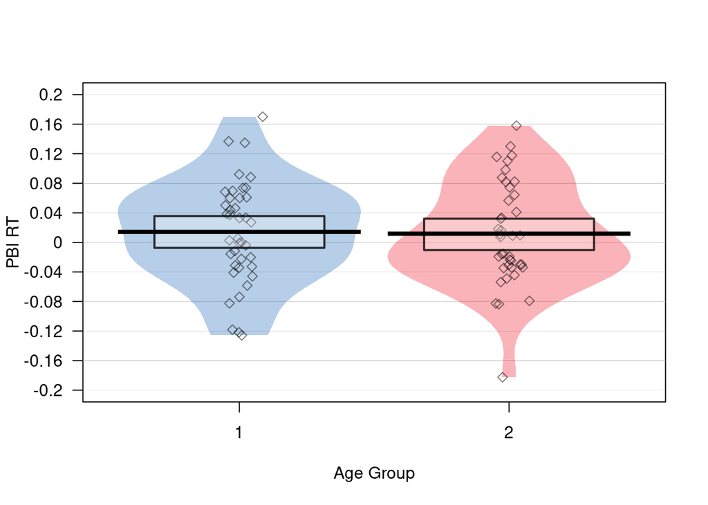

```r
#view a plot
pirateplot(formula= pbirt~factor(age_group),
           data=dt_pbirt,
           bean.f.o = .3, # customize bean (i.e. violin)
           bean.b.o= 0,
           point.o = 0.5,#customize points
            point.pch = 5,
           point.col = "black",
           point.cex = 0.9,
           inf.f.o = .3, # Inference fill
           xlab="Age Group",#labels
           ylab="PBI RT",
           theme=1)
```

## Reliability

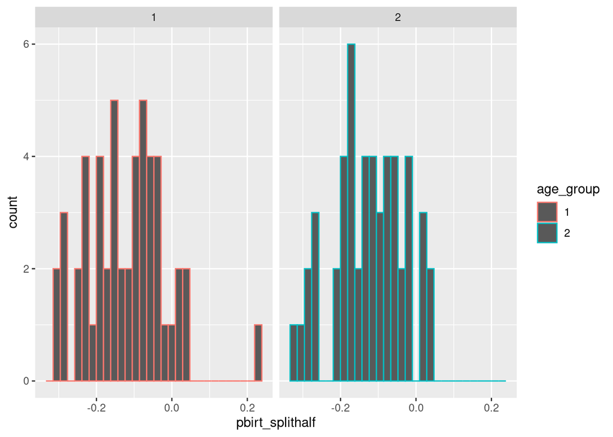

```r
#create df w/ just necessary info
dt_shr_pbirt<-dt %>%
  filter(trialtype=="ay"|trialtype=="bx") %>%
  subset(select=c(id,age_group,trialtype,rt_ms))

#create an empty dt to hold the results
shr_pbirt<-data.frame(n_rep=integer(),
                       age_group=character(),
                       pbirt_splithalf=double(),
                       pbirt_sb=double())

tot_rep<- 50 #specify number of repetition
cur_rep<-0 #counter for current repetition

while (cur_rep<=tot_rep){
  cur_rep<-cur_rep+1 #add counter

  #grab only needed trials and split into A and B halves
  tmp_dt1<-dt_shr_pbirt %>% filter(trialtype=="ay"|trialtype=="bx") %>%
    group_by(age_group, id,trialtype) %>%
    mutate(repSet=sample(
      rep(c("A","B"),length.out=n(),size=n())
    ))

  #get mean RTs for each subject, trialtype, and half
  tmp_dt2<-tmp_dt1 %>% group_by(age_group,id, trialtype, repSet) %>%
    summarise(meanrt_ms=mean(rt_ms))

  #get pbi rt_ms for each half
  tmp_dt3<-tmp_dt2 %>%
    pivot_wider(id_cols=c(id,age_group),
                names_from=c(trialtype, repSet),
                values_from=meanrt_ms) %>%
    mutate(pbirt_A=(ay_A - bx_A)/(ay_A + bx_A),
           pbirt_B=(ay_B - bx_B)/(ay_B + bx_B))

  #get corrs by age group
  tmp_dt4 <- tmp_dt3 %>% group_by(age_group) %>%
    summarise(tmp_pbirt_corr=cor(pbirt_A,pbirt_B,use="complete.obs"),
               tmp_pbirt_sb=(2*tmp_pbirt_corr)/(1+tmp_pbirt_corr))

  #add corr and sb to dataframe
  shr_pbirt<-add_row(shr_pbirt,
                      n_rep=seq(cur_rep,cur_rep,length.out=2),
                      age_group=as.factor(tmp_dt4$age_group),
                      pbirt_splithalf=tmp_dt4$tmp_pbirt_corr,
                      pbirt_sb=tmp_dt4$tmp_pbirt_sb)
}

#View(shr_pbirt) histograms by age group
ggplot(shr_pbirt, aes(x=pbirt_splithalf,color=age_group))+
  geom_histogram()+
  facet_wrap(~age_group)
```

```r
#get final split half estimates
dtsum_shr_pbirt<-shr_pbirt %>%
  group_by(age_group) %>%
  summarise(splithalf=round(mean(pbirt_splithalf),3),
            splithalf5= quantile(pbirt_splithalf,probs=c(.05,.95))[1],
            splithalf95= quantile(pbirt_splithalf,probs=c(.05,.95))[2],
            SpearmanBrown= mean(pbirt_sb),
            SpearmanBrown5= quantile(pbirt_sb,probs=c(.05,.95))[1],
            SpearmanBrown95= quantile(pbirt_sb,probs=c(.05,.95))[2])


#rearrange cols
kable_styling(kable(dtsum_shr_pbirt,digits=4,
                    caption="AXCPT: PBI rt_ms split half reliabilities (50 iterations)"))
```

AXCPT: PBI rt_ms split half reliabilities (50 iterations)

| age_group | splithalf | splithalf5 | splithalf95 | SpearmanBrown | SpearmanBrown5 | SpearmanBrown95 |
| --- | --- | --- | --- | --- | --- | --- |
| 1 | -0.123 | -0.2900 | 0.0293 | -0.3116 | -0.8170 | 0.0567 |
| 2 | -0.124 | -0.2854 | 0.0151 | -0.3089 | -0.7992 | 0.0297 |

# D-context

d’-context= Z(AX hits rate) - Z(BX false alarms rate)= ability to use cue info to drive response

## Calculation

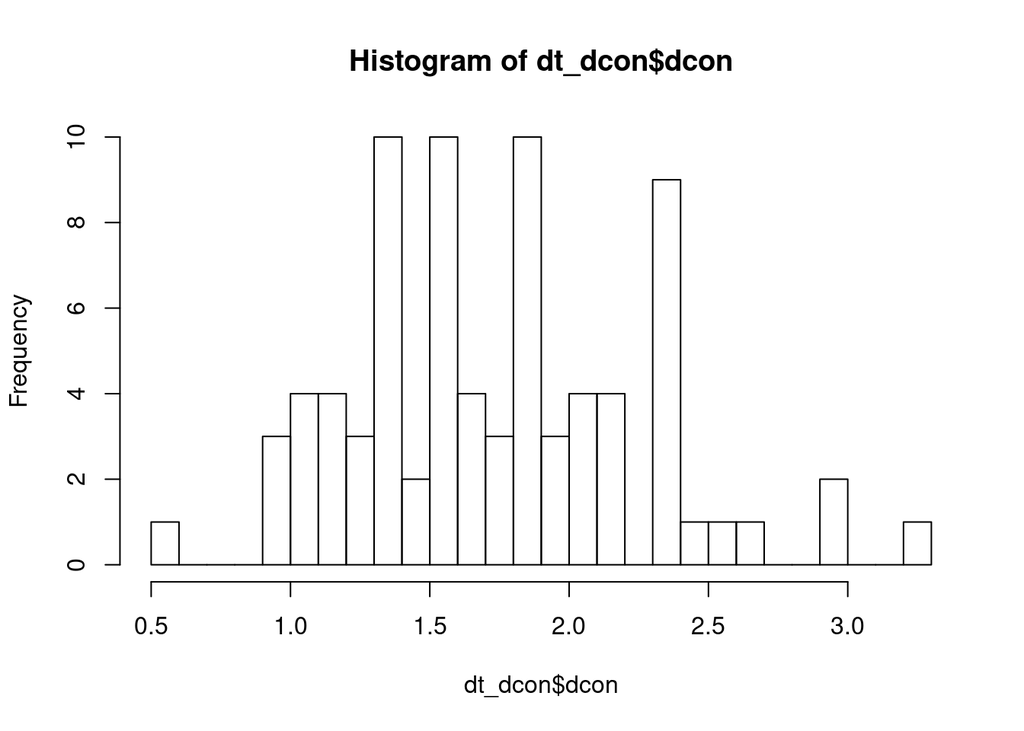

```r
#get hit rates and FA rates
dt_dcon1<-dt %>%
  group_by(id,trialtype, age_group) %>% #for each subject and trialtype
  summarise(counts= n(),
            correct=sum(acc)) %>%
  mutate(hit_rate=ifelse(correct/counts==1,.95, #get hit rates and false alarms w/ corrections
                           correct/counts),
         fa_rate=(ifelse((counts-correct)/counts==0,.05,
                  ((counts-correct)/counts))))

#now keep going
dt_dcon2<-dt_dcon1 %>%
  filter(trialtype=="ax"|trialtype=="bx") %>% #filter out AY and BY trials
  pivot_wider(id_cols = c(id,age_group),
              names_from = trialtype,
              values_from = c(hit_rate,fa_rate)) %>%
  mutate(dcon = (qnorm(hit_rate_ax) - qnorm(fa_rate_bx))) #%>%

# final dt_dcon
dt_dcon<-dt_dcon2

#view dcontext distribution
hist(dt_dcon$dcon,breaks=20)
```

## Variability

```r
leveneTest(dcon~as.factor(age_group), data=dt_dcon)
```

```
## Levene's Test for Homogeneity of Variance (center = median)
##       Df F value Pr(>F)
## group  1  0.4309 0.5135
##       78
```

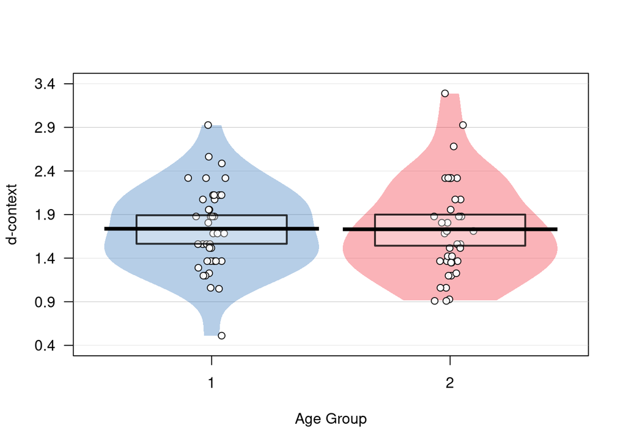

```r
#create a graph of observed variances across trialtypes by age groups
pirateplot(formula= dcon~factor(age_group),
           data=dt_dcon,
           bean.f.o = .3, # customize bean (i.e. violin)
           bean.b.o= 0,
           point.o = 0.9,#customize points
            point.pch = 21,
           point.col = "black",
           point.cex = 1,
           inf.f.o = .3, # Inference fill
           xlab="Age Group",#labels
           ylab="d-context",
           theme=1)
```

## Reliability

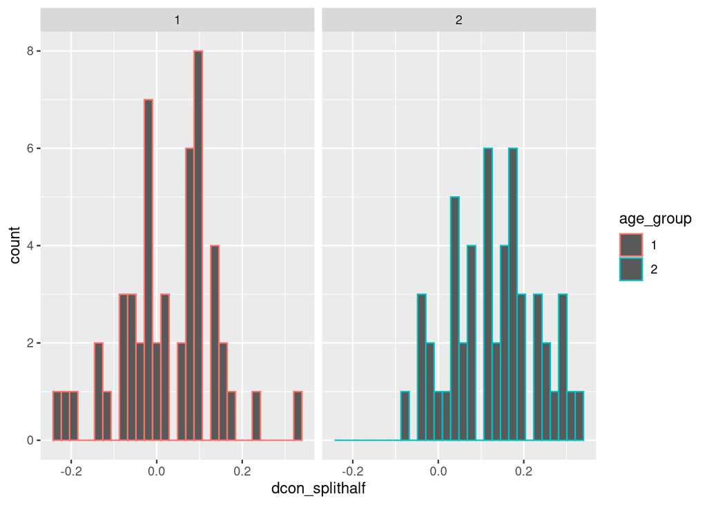

```r
#create df w/ just necessary info
dt_shr_dcon<-dt %>%
  filter(trialtype=="ax"|trialtype=="bx") %>%
  subset(select=c(id,age_group,trialtype,acc))

#empty df to store results
shr_dcon<-data.frame(n_rep=integer(),
                       age_group=character(),
                       dcon_splithalf=double(),
                       dcon_sb=double())

tot_rep<- 50 #specify number of permutations
cur_rep<-0

while (cur_rep<=tot_rep){
  cur_rep<-cur_rep+1

  tmp_dt1<-dt_shr_dcon %>%
    group_by(age_group, id,trialtype) %>%
    mutate(repSet=sample(
      rep(c("A","B"),length.out=n(),size=n())
    ))

  #get mean RTs for each subject, trialtype, and half
  tmp_dt2<- tmp_dt1 %>%
    group_by(age_group,trialtype,id,repSet) %>%
    summarise(counts= n(),
            correct=sum(acc)) %>%
    mutate(hit_rate=ifelse(correct/counts==1,.95,
                           correct/counts),
         fa_rate=(ifelse((counts-correct)/counts==0,.05,
                  ((counts-correct)/counts)))) #get hit rates and false alarms

  #now keep going
  tmp_dt3<-tmp_dt2 %>%
    pivot_wider(id_cols = c(id,repSet,age_group),
                names_from = c(trialtype),
                values_from = c(hit_rate,fa_rate)) %>%
    mutate(dcon = (qnorm(hit_rate_ax) - qnorm(fa_rate_bx))) %>%
    pivot_wider(id_cols=c(id,age_group),
                names_from=repSet,
                values_from=dcon)

  #get corrs by age group
  tmp_dt4 <- tmp_dt3 %>% group_by(age_group) %>%
    summarise(tmp_dcon_corr=cor(A,B,use="complete.obs"),
               tmp_dcon_sb=(2*tmp_dcon_corr)/(1+tmp_dcon_corr))

  #add corr and sb to dataframe
  shr_dcon<-add_row(shr_dcon,
                      n_rep=c(cur_rep, cur_rep),
                      age_group=as.factor(tmp_dt4$age_group),
                      dcon_splithalf=tmp_dt4$tmp_dcon_corr,
                      dcon_sb=tmp_dt4$tmp_dcon_sb)
}

#View(shr_dcon) histograms by age group
ggplot(shr_dcon, aes(x=dcon_splithalf,color=age_group))+
  geom_histogram()+
  facet_wrap(~age_group)
```

```r
#save output
# write.csv(shr_dcon,"05_Psychometrics/SearchCosts_AXCPT_dconSHR_201019.csv",row.names=FALSE)

#get final split half estimates
dtsum_shr_dcon<-shr_dcon %>%
  group_by(age_group) %>%
  summarise(splithalf=round(mean(dcon_splithalf),3),
            splithalf5= quantile(dcon_splithalf,probs=c(.05,.95))[1],
            splithalf95= quantile(dcon_splithalf,probs=c(.05,.95))[2],
            sb= mean(dcon_sb),
            sb5= quantile(dcon_sb,probs=c(.05,.95))[1],
            sb95= quantile(dcon_sb,probs=c(.05,.95))[2])

#rearrange cols
kable_styling(kable(dtsum_shr_dcon,digits=4,
                    caption="AXCPT: dcontext split half reliabilities (50 iterations)"))
```

AXCPT: dcontext split half reliabilities (50 iterations)

| age_group | splithalf | splithalf5 | splithalf95 | sb | sb5 | sb95 |
| --- | --- | --- | --- | --- | --- | --- |
| 1 | 0.027 | -0.1648 | 0.1647 | 0.0287 | -0.3989 | 0.2828 |
| 2 | 0.131 | -0.0360 | 0.2959 | 0.2163 | -0.0746 | 0.4567 |

# A-cue bias

A-cue bias= 1/2*(Z(AX hits rate)+Z(AY false alarms rate))= tendency to make target response to A cues

## Calculation

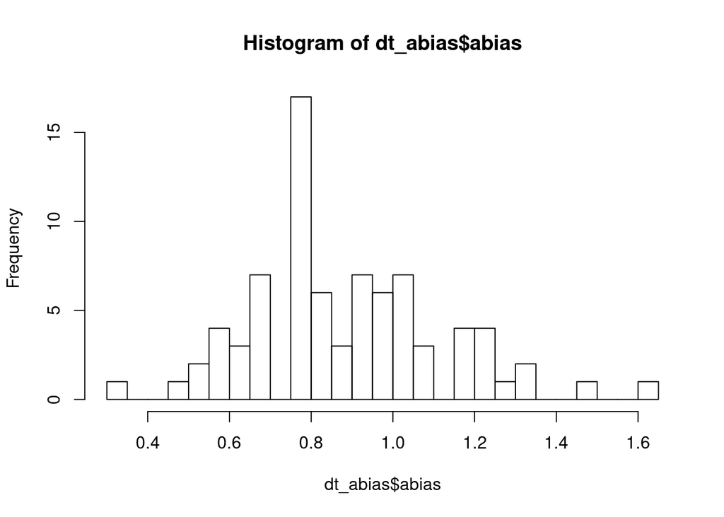

```r
#A-cue bias= 1/2*(Z(AX hits rate)+Z(AY false alarms rate))= tendency to make target response to A cues
#get hit rates and FA rates
dt_abias1<-dt %>%
  group_by(id,trialtype,age_group) %>% #for each subject and trialtype
  summarise(counts= n(),
            correct=sum(acc)) %>%
  mutate(hit_rate=ifelse(correct/counts==1,.95, #get hit rates and false alarms w/ corrections
                           correct/counts),
         fa_rate=(ifelse((counts-correct)/counts==0,.05,
                  ((counts-correct)/counts))))

#now keep going
dt_abias2<-dt_abias1 %>%
  filter(trialtype=="ax"|trialtype=="ay") %>% #filter out BX and BY trials
  pivot_wider(id_cols = c(id,age_group),
              names_from = trialtype,
              values_from = c(hit_rate,fa_rate)) %>%
  mutate(abias = 0.5*(qnorm(hit_rate_ax) - qnorm(fa_rate_ay))) #%>%

# final dt_dcon
dt_abias<-dt_abias2

#view dcontext distribution
hist(dt_abias$abias,breaks=20)
```

## Variability

```r
leveneTest(abias~as.factor(age_group),data=dt_abias)
```

```
## Levene's Test for Homogeneity of Variance (center = median)
##       Df F value Pr(>F)
## group  1  0.2606 0.6112
##       78
```

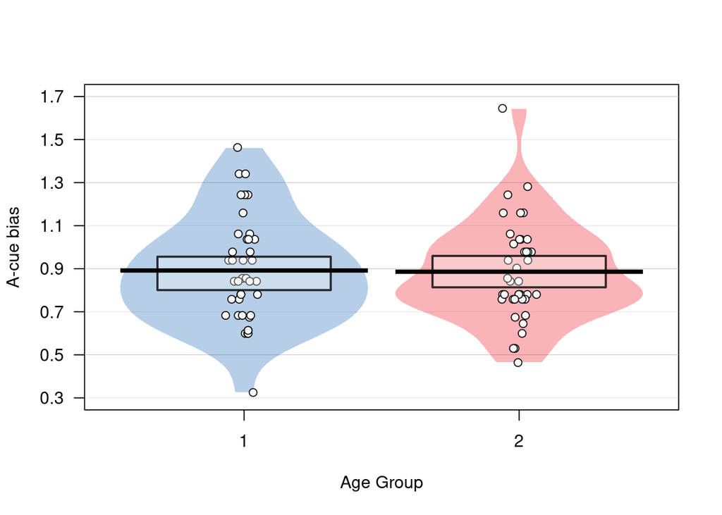

```r
#create a graph of observed variances across trialtypes by age groups
pirateplot(formula= abias~factor(age_group),
           data=dt_abias,
           bean.f.o = .3, # customize bean (i.e. violin)
           bean.b.o= 0,
           point.o = 0.9,#customize points
            point.pch = 21,
           point.col = "black",
           point.cex = 1,
           inf.f.o = .3, # Inference fill
           xlab="Age Group",#labels
           ylab="A-cue bias",
           theme=1)
```

## Reliability

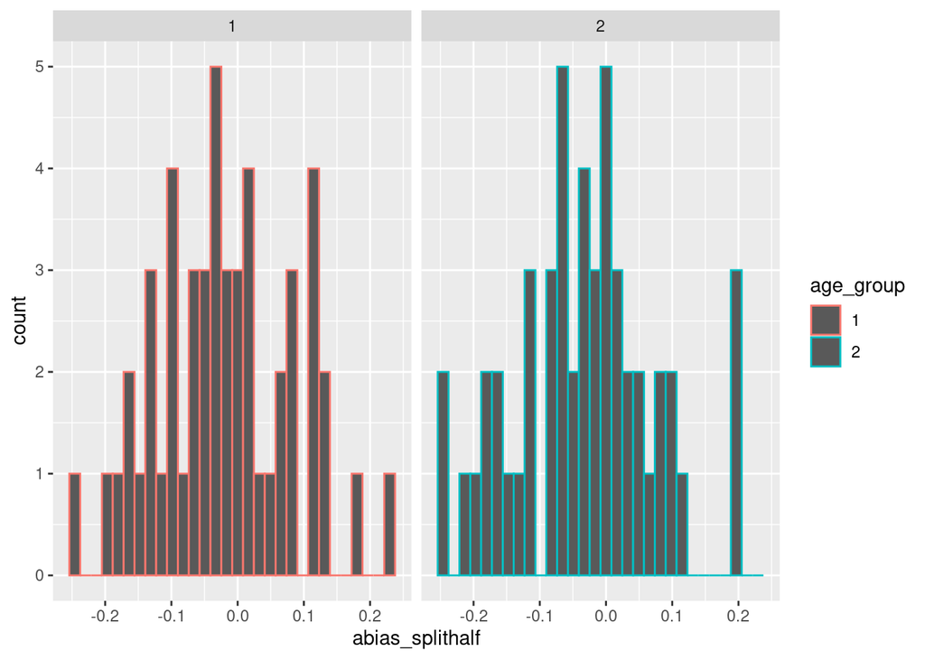

```r
#A-cue bias= 1/2*(Z(AX hits rate)+Z(AY false alarms rate))= tendency to make target response to A cues
#create df w/ just necessary info
dt_shr_abias<-dt %>%
  filter(trialtype=="ax"|trialtype=="ay") %>%
  subset(select=c(id,age_group,trialtype,acc))

shr_abias<-data.frame(n_rep=integer(),
                       age_group=character(),
                       abias_splithalf=double(),
                       abias_sb=double())

tot_rep<- 50 #specify number of permutations
cur_rep<-0

while (cur_rep<=tot_rep){
  cur_rep<-cur_rep+1

  tmp_dt1<-dt_shr_abias %>%
    group_by(age_group, id,trialtype) %>%
    mutate(repSet=sample(
      rep(c("A","B"),length.out=n(),size=n())
    ))

  #get mean RTs for each subject, trialtype, and half
  tmp_dt2<- tmp_dt1 %>%
    group_by(age_group,trialtype,id,repSet) %>%
    summarise(counts= n(),
            correct=sum(acc)) %>%
    mutate(hit_rate=ifelse(correct/counts==1,.95, #get hit rates and false alarms w/ corrections
                           correct/counts),
         fa_rate=(ifelse((counts-correct)/counts==0,.05,
                  ((counts-correct)/counts))))

  #now keep going and do calcs
  tmp_dt3<-tmp_dt2 %>%
    pivot_wider(id_cols = c(id,repSet,age_group),
                names_from = c(trialtype),
                values_from = c(hit_rate,fa_rate)) %>%
    mutate(abias = 0.5*(qnorm(hit_rate_ax) - qnorm(fa_rate_ay))) %>%
    pivot_wider(id_cols=c(id,age_group),
                names_from=repSet,
                values_from=abias)

  #get corrs by age group
  tmp_dt4 <- tmp_dt3 %>% group_by(age_group) %>%
    filter(is.finite(A) & is.finite(B)) %>%
    summarise(tmp_abias_corr=cor(A,B,use="complete.obs"),
               tmp_abias_sb=(2*tmp_abias_corr)/(1+tmp_abias_corr))

  #add corr and sb to dataframe
  shr_abias<-add_row(shr_abias,
                      n_rep=c(cur_rep, cur_rep),
                      age_group=as.factor(tmp_dt4$age_group),
                      abias_splithalf=tmp_dt4$tmp_abias_corr,
                      abias_sb=tmp_dt4$tmp_abias_sb)
}

#View(shr_abias) histograms by age group
ggplot(shr_abias, aes(x=abias_splithalf,color=age_group))+
  geom_histogram()+
  facet_wrap(~age_group)
```

```r
#get final split half estimates
dtsum_shr_abias<-shr_abias %>%
  group_by(age_group) %>%
  summarise(splithalf=round(mean(abias_splithalf),3),
            splithalf5= quantile(abias_splithalf,probs=c(.05,.95))[1],
            splithalf95= quantile(abias_splithalf,probs=c(.05,.95))[2],
            sb= mean(abias_sb),
            sb5= quantile(abias_sb,probs=c(.05,.95))[1],
            sb95= quantile(abias_sb,probs=c(.05,.95))[2])

#rearrange cols
kable_styling(kable(dtsum_shr_abias,digits=4,
                    caption="AXCPT: A-cue bias split half reliabilities (50 iterations)"))
```

AXCPT: A-cue bias split half reliabilities (50 iterations)

| age_group | splithalf | splithalf5 | splithalf95 | sb | sb5 | sb95 |
| --- | --- | --- | --- | --- | --- | --- |
| 1 | -0.020 | -0.1712 | 0.1348 | -0.0627 | -0.4132 | 0.2375 |
| 2 | -0.033 | -0.2077 | 0.1535 | -0.0947 | -0.5245 | 0.2640 |